# Acute Heat Stress: Control and A–D at the Same Level

STAT 628 — Part 1 model-building notes

Group project

Fall 2026

# 1. Data cleaning

The acute experiment has one row per plot. Each treated plot is paired with a nearby control plot that has the same year, cultivar, intensity group, and plot number. The pair is `year × cultivar × intensity_group × plot`; `plot` is a block number (1–3) within a cell, not a unique physical plot ID.

All 48 control plots are untreated (no heat lamps), so they are pooled into a single `Control` level. The four intensity groups’ control plots are **not** four different treatments; they all contribute to the same control mean. The four heat levels A–D are compared with that pooled control.

```r
d_raw <- read.csv("https://raw.githubusercontent.com/wwy200311gy-sudo/stat628/refs/heads/main/acute_yield_data_fall_2026.csv")

d <- d_raw %>%
  mutate(
    year              = factor(year),
    cultivar          = factor(toupper(trimws(cultivar))),
    intensity_group   = factor(toupper(trimws(intensity_group)),
                               levels = c("D", "C", "B", "A")),
    treatment         = factor(toupper(trimws(treatment)),
                               levels = c("CONTROL", "OTC"),
                               labels = c("Control", "OTC")),
    heat_group        = factor(
      ifelse(treatment == "Control", "Control", as.character(intensity_group)),
      levels = c("Control", "D", "C", "B", "A")
    ),
    pair              = interaction(year, cultivar, intensity_group, plot,
                                    drop = TRUE),
    total_weight      = healthy_weight + rotten_weight,
    healthy_count_pct = 100 * healthy_n / (healthy_n + rotten_n),
    healthy_weight_prop = healthy_weight / total_weight,
    healthy_weight_pct  = 100 * healthy_weight_prop,
    pulses            = as.numeric(c(A = 4, B = 3, C = 2, D = 1)[
                                      as.character(intensity_group)])
  )

# Design checks -------------------------------------------------------------
stopifnot(nrow(d) == 96, nlevels(d$pair) == 48)
stopifnot(!anyNA(d$heat_group))
stopifnot(all(d %>% count(pair) %>% pull(n) == 2))
stopifnot(all(d %>%
  group_by(pair) %>%
  summarise(ok = setequal(as.character(treatment), c("Control", "OTC")),
            .groups = "drop") %>%
  pull(ok)))
stopifnot(all(d$total_weight > 0), all(d$healthy_n + d$rotten_n > 0))

table(d$heat_group, d$treatment) %>%
  kable(caption = "Heat groups: Control is a single level; A–D are the four pulse frequencies.")
```

Heat groups: Control is a single level; A–D are the four pulse frequencies.

|  | Control | OTC |
| --- | --- | --- |
| Control | 48 | 0 |
| D | 0 | 12 |
| C | 0 | 12 |
| B | 0 | 12 |
| A | 0 | 12 |

The design is balanced: 48 control plots and 12 plots for each of A–D, i.e. 3 pairs in every year × cultivar × intensity cell. Control plots received the same insulated OTC without heat lamps, so `heat_group = Control` is the common reference for all four heat levels.

# 2. Exploratory analysis

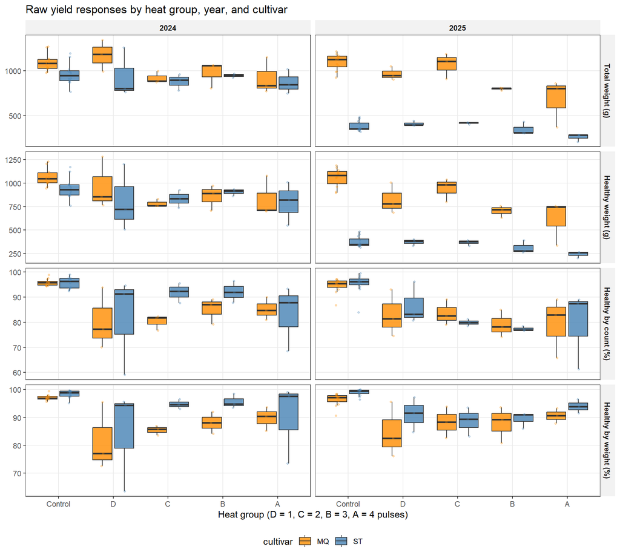

Figure 1. Raw distributions of the four yield outcomes by heat group, year, and cultivar. Rows are responses, columns are years, and colours are cultivars; nothing is averaged over year or cultivar.

```r
d_long <- d %>%
  select(year, cultivar, heat_group,
         total_weight, healthy_weight, healthy_count_pct, healthy_weight_pct) %>%
  pivot_longer(
    cols = c(total_weight, healthy_weight, healthy_count_pct, healthy_weight_pct),
    names_to = "response", values_to = "value"
  ) %>%
  mutate(response = factor(
    response,
    levels = c("total_weight", "healthy_weight", "healthy_count_pct", "healthy_weight_pct"),
    labels = c("Total weight (g)", "Healthy weight (g)",
               "Healthy by count (%)", "Healthy by weight (%)")
  ))

ggplot(d_long, aes(x = heat_group, y = value, fill = cultivar)) +
  geom_boxplot(position = position_dodge(0.8), width = 0.7,
               outlier.shape = NA, alpha = 0.8) +
  geom_point(aes(colour = cultivar),
             position = position_jitterdodge(jitter.width = 0.1,
                                             dodge.width = 0.8),
             alpha = 0.3, size = 0.9, show.legend = FALSE) +
  facet_grid(response ~ year, scales = "free_y") +
  scale_fill_manual(values = c(MQ = "darkorange", ST = "steelblue")) +
  scale_colour_manual(values = c(MQ = "darkorange", ST = "steelblue")) +
  labs(x = "Heat group (D = 1, C = 2, B = 3, A = 4 pulses)",
       y = NULL, title = "Raw yield responses by heat group, year, and cultivar") +
  theme_report()
```

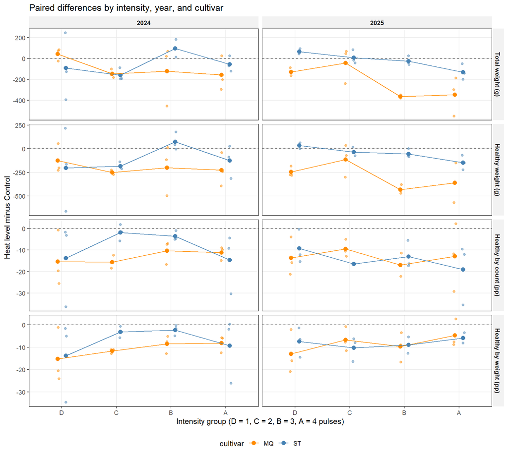

Figure 2. Within-pair differences (heat level minus its paired Control) by intensity, year, and cultivar. Each point is a plot pair; the coloured points and lines are cultivar-specific means.

```r
d_diff <- d %>%
  select(pair, year, cultivar, intensity_group, treatment,
         total_weight, healthy_weight, healthy_count_pct, healthy_weight_pct) %>%
  pivot_longer(
    cols = c(total_weight, healthy_weight, healthy_count_pct, healthy_weight_pct),
    names_to = "response", values_to = "value"
  ) %>%
  pivot_wider(names_from = treatment, values_from = value) %>%
  mutate(
    diff = OTC - Control,
    response = factor(
      response,
      levels = c("total_weight", "healthy_weight", "healthy_count_pct", "healthy_weight_pct"),
      labels = c("Total weight (g)", "Healthy weight (g)",
                 "Healthy by count (pp)", "Healthy by weight (pp)")
    )
  )

ggplot(d_diff, aes(x = intensity_group, y = diff, colour = cultivar)) +
  geom_hline(yintercept = 0, linetype = 2, colour = "grey35") +
  geom_point(position = position_jitterdodge(jitter.width = 0.1,
                                             dodge.width = 0.3),
             alpha = 0.5, size = 1.5) +
  stat_summary(fun = mean, geom = "point",
               position = position_dodge(0.3), size = 2.5) +
  stat_summary(fun = mean, geom = "line", aes(group = cultivar),
               position = position_dodge(0.3)) +
  facet_grid(response ~ year, scales = "free_y") +
  scale_colour_manual(values = c(MQ = "darkorange", ST = "steelblue")) +
  labs(x = "Intensity group (D = 1, C = 2, B = 3, A = 4 pulses)",
       y = "Heat level minus Control",
       title = "Paired differences by intensity, year, and cultivar") +
  theme_report()
```

```r
d %>%
  group_by(year, cultivar, heat_group) %>%
  summarise(across(c(total_weight, healthy_weight,
                     healthy_count_pct, healthy_weight_pct), mean),
            .groups = "drop") %>%
  pivot_longer(cols = c(total_weight, healthy_weight,
                        healthy_count_pct, healthy_weight_pct),
               names_to = "response", values_to = "mean") %>%
  mutate(response = factor(response,
                           levels = c("total_weight", "healthy_weight",
                                      "healthy_count_pct", "healthy_weight_pct"),
                           labels = c("Total weight", "Healthy weight",
                                      "Count %", "Weight %")),
         col = paste(year, cultivar)) %>%
  select(heat_group, response, col, mean) %>%
  pivot_wider(names_from = col, values_from = mean) %>%
  arrange(response, heat_group) %>%
  kable(digits = 1,
        col.names = c("Heat group", "Response", "2024 MQ", "2024 ST",
                      "2025 MQ", "2025 ST"),
        caption = "Raw arithmetic means by heat group, year, and cultivar (not adjusted for design).")
```

Raw arithmetic means by heat group, year, and cultivar (not adjusted for design).

| Heat group | Response | 2024 MQ | 2024 ST | 2025 MQ | 2025 ST |
| --- | --- | --- | --- | --- | --- |
| Control | Total weight | 1091.5 | 961.3 | 1096.5 | 378.6 |
| D | Total weight | 1171.3 | 939.9 | 965.0 | 408.6 |
| C | Total weight | 917.3 | 878.0 | 1065.5 | 414.9 |
| B | Total weight | 973.4 | 945.4 | 797.3 | 347.8 |
| A | Total weight | 919.3 | 869.1 | 676.5 | 258.3 |
| Control | Healthy weight | 1059.7 | 945.1 | 1057.5 | 374.4 |
| D | Healthy weight | 967.6 | 810.0 | 823.4 | 372.4 |
| C | Healthy weight | 782.8 | 832.2 | 939.0 | 368.5 |
| B | Healthy weight | 857.4 | 904.4 | 701.6 | 311.5 |
| A | Healthy weight | 828.9 | 793.4 | 612.1 | 242.1 |
| Control | Count % | 95.8 | 95.6 | 94.5 | 95.2 |
| D | Count % | 80.4 | 81.6 | 83.0 | 86.6 |
| C | Count % | 80.3 | 91.8 | 83.5 | 79.9 |
| B | Count % | 85.1 | 92.0 | 79.1 | 77.3 |
| A | Count % | 85.2 | 83.2 | 79.3 | 79.2 |
| Control | Weight % | 97.1 | 98.4 | 96.4 | 98.9 |
| D | Weight % | 81.7 | 84.5 | 84.8 | 91.2 |
| C | Weight % | 85.4 | 94.7 | 88.3 | 88.7 |
| B | Weight % | 88.1 | 95.6 | 87.9 | 89.4 |
| A | Weight % | 89.7 | 90.1 | 90.6 | 94.0 |

The weight entries above are raw arithmetic means. The model-based weight means in the next sections are geometric means and are lower (e.g. 808 g for Control total weight); the ratio and percentage-change estimates are unaffected by this distinction.

Figure 1 puts Control and A–D on the same x-axis and separates years (columns) and cultivars (colours); Figure 2 does the same for the paired differences, so the cultivar and year patterns are visible rather than averaged away. The weight differences become more negative with more pulses, while the percentage differences are already large at one pulse. The models below test whether these patterns are consistent across cultivars and years.

# 3. Model families and candidate structure

| Response | Family | Why |
| --- | --- | --- |
| Total weight | log-normal LMM | positive, right-skewed; variance grows with the mean |
| Healthy weight | log-normal LMM | same |
| Healthy % by count | beta-binomial GLMM (logit) | counts with extra-binomial variation |
| Healthy % by weight | beta GLMM (logit) | continuous proportion in (0, 1) |

The LMMs are fitted with `lme4::lmer`; the GLMMs with `glmmTMB`. All models have a **pair random intercept** `(1 | pair)`. `heat_group` varies within a pair (Control vs the paired heat level), so the heat effects are within-pair contrasts; cultivar and year vary between pairs.

The candidate fixed-effect structures are:

| Model | Mean structure | Purpose |
| --- | --- | --- |
| H0 | `heat_group + cultivar + year + year:cultivar` | additive 5-level model (common control) |
| H1 | `heat_group * cultivar + year + year:cultivar` | does the heat profile differ by cultivar? |
| H2 | `heat_group * year + cultivar + year:cultivar` | does the heat profile differ by year? |
| H3 | `heat_group * (cultivar + year) + year:cultivar` | both |
| H4 | `treatment * intensity_group + cultivar + year + year:cultivar` | design check only: separate control means (not a candidate) |

H0 has 5 group means (Control, A, B, C, D). All control plots are untreated and pooled into one Control level, so the model estimates a single control mean. H4 is **not a candidate model**: it is a design check with separate control means (8 cell means). H0 is H4 with the three constraints `Control_A = Control_B = Control_C = Control_D`, so the H0-vs-H4 test has 3 df and checks whether the design-based pooling is supported by the data.

# 4. Model comparison

```r
fit_lmm <- function(form) lmer(form, data = d, REML = FALSE)
fit_bb <- function(form) glmmTMB(form, data = d, family = betabinomial(),
                                 dispformula = ~ treatment)
fit_beta <- function(form) glmmTMB(form, data = d, family = beta_family(),
                                  dispformula = ~ treatment)

# Total weight
h0_total <- fit_lmm(log(total_weight) ~ heat_group + cultivar + year +
                      year:cultivar + (1 | pair))
h1_total <- fit_lmm(log(total_weight) ~ heat_group * cultivar + year +
                      year:cultivar + (1 | pair))
h2_total <- fit_lmm(log(total_weight) ~ heat_group * year + cultivar +
                      year:cultivar + (1 | pair))
h3_total <- fit_lmm(log(total_weight) ~ heat_group * (cultivar + year) +
                      year:cultivar + (1 | pair))
h4_total <- fit_lmm(log(total_weight) ~ treatment * intensity_group +
                      cultivar + year + year:cultivar + (1 | pair))

# Healthy weight
h0_healthy <- fit_lmm(log(healthy_weight) ~ heat_group + cultivar + year +
                        year:cultivar + (1 | pair))
h1_healthy <- fit_lmm(log(healthy_weight) ~ heat_group * cultivar + year +
                        year:cultivar + (1 | pair))
h2_healthy <- fit_lmm(log(healthy_weight) ~ heat_group * year + cultivar +
                        year:cultivar + (1 | pair))
h3_healthy <- fit_lmm(log(healthy_weight) ~ heat_group * (cultivar + year) +
                        year:cultivar + (1 | pair))
h4_healthy <- fit_lmm(log(healthy_weight) ~ treatment * intensity_group +
                        cultivar + year + year:cultivar + (1 | pair))

# Count percentage
h0_count <- fit_bb(cbind(healthy_n, rotten_n) ~ heat_group + cultivar + year +
                     year:cultivar + (1 | pair))
h1_count <- fit_bb(cbind(healthy_n, rotten_n) ~ heat_group * cultivar + year +
                     year:cultivar + (1 | pair))
h2_count <- fit_bb(cbind(healthy_n, rotten_n) ~ heat_group * year + cultivar +
                     year:cultivar + (1 | pair))
h3_count <- fit_bb(cbind(healthy_n, rotten_n) ~ heat_group * (cultivar + year) +
                     year:cultivar + (1 | pair))
h4_count <- fit_bb(cbind(healthy_n, rotten_n) ~ treatment * intensity_group +
                     cultivar + year + year:cultivar + (1 | pair))

# Weight percentage
h0_wpct <- fit_beta(healthy_weight_prop ~ heat_group + cultivar + year +
                      year:cultivar + (1 | pair))
h1_wpct <- fit_beta(healthy_weight_prop ~ heat_group * cultivar + year +
                      year:cultivar + (1 | pair))
h2_wpct <- fit_beta(healthy_weight_prop ~ heat_group * year + cultivar +
                      year:cultivar + (1 | pair))
h3_wpct <- fit_beta(healthy_weight_prop ~ heat_group * (cultivar + year) +
                      year:cultivar + (1 | pair))
h4_wpct <- fit_beta(healthy_weight_prop ~ treatment * intensity_group +
                      cultivar + year + year:cultivar + (1 | pair))

aic_tab <- bind_rows(
  data.frame(Response = "Total",   Model = c("H0", "H1", "H2", "H3"),
             df = sapply(list(h0_total, h1_total, h2_total, h3_total),
                         function(m) attr(logLik(m), "df")),
             AIC = sapply(list(h0_total, h1_total, h2_total, h3_total), AIC)),
  data.frame(Response = "Healthy", Model = c("H0", "H1", "H2", "H3"),
             df = sapply(list(h0_healthy, h1_healthy, h2_healthy, h3_healthy),
                         function(m) attr(logLik(m), "df")),
             AIC = sapply(list(h0_healthy, h1_healthy, h2_healthy, h3_healthy), AIC)),
  data.frame(Response = "Count",   Model = c("H0", "H1", "H2", "H3"),
             df = sapply(list(h0_count, h1_count, h2_count, h3_count),
                         function(m) attr(logLik(m), "df")),
             AIC = sapply(list(h0_count, h1_count, h2_count, h3_count), AIC)),
  data.frame(Response = "Weight",  Model = c("H0", "H1", "H2", "H3"),
             df = sapply(list(h0_wpct, h1_wpct, h2_wpct, h3_wpct),
                         function(m) attr(logLik(m), "df")),
             AIC = sapply(list(h0_wpct, h1_wpct, h2_wpct, h3_wpct), AIC))
) %>%
  group_by(Response) %>%
  mutate(dAIC = AIC - min(AIC)) %>%
  ungroup()

kable(aic_tab, digits = 2,
      caption = "AIC comparison of the 5-level heat_group candidate models (ML fits). H4 (separate control means) is a design check, not a candidate.")
```

AIC comparison of the 5-level heat_group candidate models (ML fits). H4 (separate control means) is a design check, not a candidate.

| Response | Model | df | AIC | dAIC |
| --- | --- | --- | --- | --- |
| Total | H0 | 10 | -71.59 | 13.01 |
| Total | H1 | 14 | -68.64 | 15.96 |
| Total | H2 | 14 | -84.60 | 0.00 |
| Total | H3 | 18 | -83.69 | 0.91 |
| Healthy | H0 | 10 | -46.85 | 6.31 |
| Healthy | H1 | 14 | -43.82 | 9.34 |
| Healthy | H2 | 14 | -53.17 | 0.00 |
| Healthy | H3 | 18 | -51.45 | 1.72 |
| Count | H0 | 11 | 842.71 | 0.00 |
| Count | H1 | 15 | 849.97 | 7.26 |
| Count | H2 | 15 | 846.21 | 3.51 |
| Count | H3 | 19 | 853.58 | 10.87 |
| Weight | H0 | 11 | -406.40 | 0.00 |
| Weight | H1 | 15 | -402.17 | 4.23 |
| Weight | H2 | 15 | -399.96 | 6.43 |
| Weight | H3 | 19 | -395.98 | 10.41 |

```r
lrt_row <- function(m_small, m_big, label) {
  a <- anova(m_small, m_big)
  df_col <- if ("Chi Df" %in% names(a)) a[["Chi Df"]] else a[["Df"]]
  data.frame(Test = label, Chisq = a$Chisq[2], df = df_col[2],
             p = a$`Pr(>Chisq)`[2])
}

bind_rows(
  lrt_row(h0_total,   h1_total,   "Total: heat × cultivar"),
  lrt_row(h0_total,   h2_total,   "Total: heat × year"),
  lrt_row(h0_total,   h3_total,   "Total: heat × (cultivar + year)"),
  lrt_row(h0_healthy, h1_healthy, "Healthy: heat × cultivar"),
  lrt_row(h0_healthy, h2_healthy, "Healthy: heat × year"),
  lrt_row(h0_healthy, h3_healthy, "Healthy: heat × (cultivar + year)"),
  lrt_row(h0_count,   h1_count,   "Count: heat × cultivar"),
  lrt_row(h0_count,   h2_count,   "Count: heat × year"),
  lrt_row(h0_count,   h3_count,   "Count: heat × (cultivar + year)"),
  lrt_row(h0_wpct,    h1_wpct,    "Weight: heat × cultivar"),
  lrt_row(h0_wpct,    h2_wpct,    "Weight: heat × year"),
  lrt_row(h0_wpct,    h3_wpct,    "Weight: heat × (cultivar + year)")
) %>%
  mutate(p = fmt_p(p)) %>%
  kable(digits = 3, caption = "Likelihood-ratio tests for the 5-level heat_group candidate models.")
```

Likelihood-ratio tests for the 5-level heat_group candidate models.

| Test | Chisq | df | p |
| --- | --- | --- | --- |
| Total: heat × cultivar | 5.043 | 4 | 0.283 |
| Total: heat × year | 21.005 | 4 | <0.001 |
| Total: heat × (cultivar + year) | 28.094 | 8 | <0.001 |
| Healthy: heat × cultivar | 4.970 | 4 | 0.290 |
| Healthy: heat × year | 14.312 | 4 | 0.006 |
| Healthy: heat × (cultivar + year) | 20.593 | 8 | 0.008 |
| Count: heat × cultivar | 0.735 | 4 | 0.947 |
| Count: heat × year | 4.495 | 4 | 0.343 |
| Count: heat × (cultivar + year) | 5.129 | 8 | 0.744 |
| Weight: heat × cultivar | 3.769 | 4 | 0.438 |
| Weight: heat × year | 1.565 | 4 | 0.815 |
| Weight: heat × (cultivar + year) | 5.587 | 8 | 0.693 |

```r
bind_rows(
  lrt_row(h0_total,   h4_total,   "Total"),
  lrt_row(h0_healthy, h4_healthy, "Healthy"),
  lrt_row(h0_count,   h4_count,   "Count"),
  lrt_row(h0_wpct,    h4_wpct,    "Weight")
) %>%
  mutate(p = fmt_p(p)) %>%
  kable(digits = 3,
        caption = "Design check: pooled control (H0) vs separate control means (H4). H4 is not a candidate model.")
```

Design check: pooled control (H0) vs separate control means (H4). H4 is not a candidate model.

| Test | Chisq | df | p |
| --- | --- | --- | --- |
| Total | 1.060 | 3 | 0.787 |
| Healthy | 0.654 | 3 | 0.884 |
| Count | 5.833 | 3 | 0.120 |
| Weight | 6.186 | 3 | 0.103 |

**What the comparison says.**

- **Total and healthy weight**: `heat_group × year` is strongly supported (p = 0.0003 and p = 0.006), while `heat_group × cultivar` is not (p = 0.28 and p = 0.29). The pooled-control model is used by design; the separate-control check is not significant (p = 0.79 and p = 0.88). The selected weight model is **H2**: `heat_group * year + cultivar + year:cultivar`. The heat profile differs between 2024 and 2025, but not between MQ and ST.
- **Count percentage**: no heat interaction is supported (heat × cultivar p = 0.95, heat × year p = 0.34, both p = 0.74). The pooled-control model is used by design; the separate-control check is not significant (p = 0.12). The selected model is additive, **H0**.
- **Weight percentage**: no heat interaction is supported (heat × cultivar p = 0.44, heat × year p = 0.82, both p = 0.69). The pooled-control model is used by design; the separate-control check is borderline but not significant (p = 0.10). The selected model is additive, **H0**. H4 uses three extra parameters for the separate control means; with p = 0.10 for the pooling check, H0 is preferred for parsimony.

For the percentage outcomes, `year:cultivar` is also not supported (count p = 0.69, weight p = 0.67), so the final additive model drops it:

```r
f_count <- glmmTMB(cbind(healthy_n, rotten_n) ~ heat_group + cultivar + year +
                     (1 | pair),
                   data = d, family = betabinomial(),
                   dispformula = ~ treatment)
f_wpct <- glmmTMB(healthy_weight_prop ~ heat_group + cultivar + year +
                    (1 | pair),
                  data = d, family = beta_family(),
                  dispformula = ~ treatment)

aic_pct <- AIC(h0_count, f_count, h0_wpct, f_wpct)
kable(data.frame(Model = rownames(aic_pct), aic_pct, row.names = NULL),
      digits = 2,
      caption = "AIC for the additive percentage models with and without year:cultivar.")
```

AIC for the additive percentage models with and without year:cultivar.

| Model | df | AIC |
| --- | --- | --- |
| h0_count | 11 | 842.71 |
| f_count | 10 | 840.87 |
| h0_wpct | 11 | -406.40 |
| f_wpct | 10 | -408.21 |

# 5. Final models

The final models are:

```r
# weights: heat profile varies by year, not by cultivar
log(weight) ~ heat_group * year + cultivar + year:cultivar + (1 | pair)

# percentages: additive 5-level heat effect
count_pct  ~ heat_group + cultivar + year + (1 | pair)   # beta-binomial
weight_pct ~ heat_group + cultivar + year + (1 | pair)   # beta
```

```r
f_total <- lmer(log(total_weight) ~ heat_group * year + cultivar +
                  year:cultivar + (1 | pair),
                data = d, REML = TRUE)
f_healthy <- lmer(log(healthy_weight) ~ heat_group * year + cultivar +
                    year:cultivar + (1 | pair),
                  data = d, REML = TRUE)

tidy_lmm <- function(m) {
  s <- summary(m)$coefficients
  data.frame(Term = rownames(s), Estimate = s[, 1], SE = s[, 2], t = s[, 3],
             row.names = NULL)
}
tidy_glmm <- function(m) {
  s <- summary(m)$coefficients$cond
  data.frame(Term = rownames(s), Estimate = s[, 1], SE = s[, 2],
             z = s[, 3], p = s[, 4], row.names = NULL)
}

kable(tidy_lmm(f_total), digits = 3,
      caption = "Final model: log(total weight), heat_group × year + cultivar + year:cultivar.")
```

Final model: log(total weight), heat_group × year + cultivar + year:cultivar.

| Term | Estimate | SE | t |
| --- | --- | --- | --- |
| (Intercept) | 6.981 | 0.037 | 186.688 |
| heat_groupD | 0.003 | 0.063 | 0.041 |
| heat_groupC | -0.135 | 0.063 | -2.142 |
| heat_groupB | -0.054 | 0.063 | -0.852 |
| heat_groupA | -0.139 | 0.063 | -2.198 |
| year2025 | -0.031 | 0.053 | -0.578 |
| cultivarST | -0.110 | 0.046 | -2.405 |
| heat_groupD:year2025 | -0.015 | 0.089 | -0.173 |
| heat_groupC:year2025 | 0.162 | 0.089 | 1.816 |
| heat_groupB:year2025 | -0.153 | 0.089 | -1.720 |
| heat_groupA:year2025 | -0.321 | 0.089 | -3.603 |
| year2025:cultivarST | -0.868 | 0.065 | -13.460 |

```r
kable(tidy_lmm(f_healthy), digits = 3,
      caption = "Final model: log(healthy weight), heat_group × year + cultivar + year:cultivar.")
```

Final model: log(healthy weight), heat_group × year + cultivar + year:cultivar.

| Term | Estimate | SE | t |
| --- | --- | --- | --- |
| (Intercept) | 6.942 | 0.043 | 160.519 |
| heat_groupD | -0.168 | 0.076 | -2.215 |
| heat_groupC | -0.216 | 0.076 | -2.850 |
| heat_groupB | -0.121 | 0.076 | -1.599 |
| heat_groupA | -0.230 | 0.076 | -3.036 |
| year2025 | -0.031 | 0.061 | -0.499 |
| cultivarST | -0.078 | 0.052 | -1.504 |
| heat_groupD:year2025 | 0.043 | 0.107 | 0.399 |
| heat_groupC:year2025 | 0.147 | 0.107 | 1.375 |
| heat_groupB:year2025 | -0.182 | 0.107 | -1.702 |
| heat_groupA:year2025 | -0.289 | 0.107 | -2.698 |
| year2025:cultivarST | -0.870 | 0.073 | -11.921 |

```r
kable(tidy_glmm(f_count), digits = 3,
      caption = "Final model: healthy percentage by count (beta-binomial), additive.")
```

Final model: healthy percentage by count (beta-binomial), additive.

| Term | Estimate | SE | z | p |
| --- | --- | --- | --- | --- |
| (Intercept) | 3.052 | 0.107 | 28.402 | 0.000 |
| heat_groupD | -1.349 | 0.186 | -7.259 | 0.000 |
| heat_groupC | -1.419 | 0.181 | -7.825 | 0.000 |
| heat_groupB | -1.438 | 0.181 | -7.962 | 0.000 |
| heat_groupA | -1.510 | 0.179 | -8.432 | 0.000 |
| cultivarST | 0.152 | 0.110 | 1.385 | 0.166 |
| year2025 | -0.214 | 0.110 | -1.947 | 0.052 |

```r
kable(tidy_glmm(f_wpct), digits = 3,
      caption = "Final model: healthy percentage by weight (beta), additive.")
```

Final model: healthy percentage by weight (beta), additive.

| Term | Estimate | SE | z | p |
| --- | --- | --- | --- | --- |
| (Intercept) | 3.422 | 0.129 | 26.539 | 0.000 |
| heat_groupD | -1.852 | 0.202 | -9.177 | 0.000 |
| heat_groupC | -1.742 | 0.207 | -8.432 | 0.000 |
| heat_groupB | -1.621 | 0.213 | -7.627 | 0.000 |
| heat_groupA | -1.443 | 0.222 | -6.509 | 0.000 |
| cultivarST | 0.747 | 0.137 | 5.435 | 0.000 |
| year2025 | 0.045 | 0.129 | 0.349 | 0.727 |

## 5.1 Overall heat effect and A–D versus Control

The **average heat effect** is the average of the four heat levels minus the common Control: the contrast `(-1, 1/4, 1/4, 1/4, 1/4)` over Control, D, C, B, A. This is the natural “heat vs no heat” summary when Control and A–D are at the same level. The **A–D versus Control** contrasts show which pulse frequencies differ from Control; Holm adjustment is applied within the four contrasts.

```r
avg_heat <- function(fit, by = NULL, type = c("weight", "prop")) {
  type <- match.arg(type)
  if (is.null(by)) {
    em <- emmeans(fit, ~ heat_group)
  } else {
    em <- emmeans(fit, as.formula(paste("~ heat_group |", by)))
  }
  if (type == "weight") {
    contrast(em, list("Heat avg vs Control" = c(-1, .25, .25, .25, .25)),
             type = "response")
  } else {
    contrast(regrid(em, "response"),
             list("Heat avg vs Control" = c(-1, .25, .25, .25, .25)))
  }
}

ad_heat <- function(fit, by = NULL, type = c("weight", "prop")) {
  type <- match.arg(type)
  if (is.null(by)) {
    em <- emmeans(fit, ~ heat_group)
  } else {
    em <- emmeans(fit, as.formula(paste("~ heat_group |", by)))
  }
  if (type == "weight") {
    contrast(em, "trt.vs.ctrl", ref = "Control", type = "response",
             adjust = "holm")
  } else {
    contrast(regrid(em, "response"), "trt.vs.ctrl", ref = "Control",
             adjust = "holm")
  }
}

linear_heat <- function(fit, by = NULL) {
  if (is.null(by)) {
    em <- emmeans(fit, ~ heat_group)
  } else {
    em <- emmeans(fit, as.formula(paste("~ heat_group |", by)))
  }
  # per-pulse linear contrast among D, C, B, A; Control has weight 0
  contrast(em, list("Per-pulse trend" = c(0, -0.3, -0.1, 0.1, 0.3)),
           type = "response")
}

cat("=== average heat vs Control (weights) ===\n")
```

```
=== average heat vs Control (weights) ===
```

```r
for (m in list(total = f_total, healthy = f_healthy)) {
  print(avg_heat(m, type = "weight"))
  print(avg_heat(m, by = "year", type = "weight"))
}
```

```
 contrast            ratio     SE   df null t.ratio p.value
 Heat avg vs Control 0.885 0.0237 40.9    1  -4.568 <0.0001

Results are averaged over the levels of: year, cultivar
Degrees-of-freedom method: kenward-roger
Tests are performed on the log scale
year = 2024:
 contrast            ratio     SE   df null t.ratio p.value
 Heat avg vs Control 0.922 0.0349 40.9    1  -2.146  0.0378

year = 2025:
 contrast            ratio     SE   df null t.ratio p.value
 Heat avg vs Control 0.849 0.0321 40.9    1  -4.314 <0.0001

Results are averaged over the levels of: cultivar
Degrees-of-freedom method: kenward-roger
Tests are performed on the log scale
```

```
 contrast            ratio     SE   df null t.ratio p.value
 Heat avg vs Control 0.804 0.0264 41.1    1  -6.664 <0.0001

Results are averaged over the levels of: year, cultivar
Degrees-of-freedom method: kenward-roger
Tests are performed on the log scale
year = 2024:
 contrast            ratio     SE   df null t.ratio p.value
 Heat avg vs Control 0.832 0.0386 41.1    1  -3.955  0.0003

year = 2025:
 contrast            ratio     SE   df null t.ratio p.value
 Heat avg vs Control 0.776 0.0360 41.1    1  -5.470 <0.0001

Results are averaged over the levels of: cultivar
Degrees-of-freedom method: kenward-roger
Tests are performed on the log scale
```

```r
cat("\n=== A-D vs Control (weights, Holm within 4) ===\n")
```

```
=== A-D vs Control (weights, Holm within 4) ===
```

```r
for (m in list(total = f_total, healthy = f_healthy)) {
  print(ad_heat(m, type = "weight"))
  print(ad_heat(m, by = "year", type = "weight"))
}
```

```
 contrast    ratio     SE df null t.ratio p.value
 D / Control 0.995 0.0450 68    1  -0.113  0.9101
 C / Control 0.947 0.0429 68    1  -1.194  0.4734
 B / Control 0.878 0.0397 68    1  -2.879  0.0160
 A / Control 0.741 0.0336 68    1  -6.608 <0.0001

Results are averaged over the levels of: year, cultivar
Degrees-of-freedom method: kenward-roger
P value adjustment: holm method for 4 tests
Tests are performed on the log scale
year = 2024:
 contrast    ratio     SE df null t.ratio p.value
 D / Control 1.003 0.0642 68    1   0.040  0.9680
 C / Control 0.874 0.0559 68    1  -2.109  0.1359
 B / Control 0.948 0.0607 68    1  -0.839  0.8094
 A / Control 0.871 0.0557 68    1  -2.164  0.1359

year = 2025:
 contrast    ratio     SE df null t.ratio p.value
 D / Control 0.987 0.0632 68    1  -0.200  1.0000
 C / Control 1.027 0.0658 68    1   0.420  1.0000
 B / Control 0.813 0.0521 68    1  -3.233  0.0057
 A / Control 0.631 0.0404 68    1  -7.181 <0.0001

Results are averaged over the levels of: cultivar
Degrees-of-freedom method: kenward-roger
P value adjustment: holm method for 4 tests
Tests are performed on the log scale
```

```
 contrast    ratio     SE   df null t.ratio p.value
 D / Control 0.864 0.0469 70.2    1  -2.691  0.0178
 C / Control 0.868 0.0471 70.2    1  -2.615  0.0178
 B / Control 0.809 0.0439 70.2    1  -3.902  0.0006
 A / Control 0.688 0.0374 70.2    1  -6.883 <0.0001

Results are averaged over the levels of: year, cultivar
Degrees-of-freedom method: kenward-roger
P value adjustment: holm method for 4 tests
Tests are performed on the log scale
year = 2024:
 contrast    ratio     SE   df null t.ratio p.value
 D / Control 0.846 0.0650 70.2    1  -2.181  0.0651
 C / Control 0.806 0.0619 70.2    1  -2.806  0.0195
 B / Control 0.886 0.0681 70.2    1  -1.574  0.1200
 A / Control 0.795 0.0611 70.2    1  -2.989  0.0154

year = 2025:
 contrast    ratio     SE   df null t.ratio p.value
 D / Control 0.883 0.0678 70.2    1  -1.625  0.2173
 C / Control 0.934 0.0717 70.2    1  -0.892  0.3755
 B / Control 0.739 0.0567 70.2    1  -3.944  0.0006
 A / Control 0.596 0.0458 70.2    1  -6.746 <0.0001

Results are averaged over the levels of: cultivar
Degrees-of-freedom method: kenward-roger
P value adjustment: holm method for 4 tests
Tests are performed on the log scale
```

```r
cat("\n=== per-pulse trend among A-D (weights) ===\n")
```

```
=== per-pulse trend among A-D (weights) ===
```

```r
for (m in list(total = f_total, healthy = f_healthy)) {
  print(linear_heat(m))
  print(linear_heat(m, by = "year"))
}
```

```
 contrast        ratio     SE   df null t.ratio p.value
 Per-pulse trend 0.909 0.0171 81.3    1  -5.080 <0.0001

Results are averaged over the levels of: year, cultivar
Degrees-of-freedom method: kenward-roger
Tests are performed on the log scale
year = 2024:
 contrast        ratio     SE   df null t.ratio p.value
 Per-pulse trend 0.966 0.0258 81.3    1  -1.282  0.2034

year = 2025:
 contrast        ratio     SE   df null t.ratio p.value
 Per-pulse trend 0.854 0.0228 81.3    1  -5.903 <0.0001

Results are averaged over the levels of: cultivar
Degrees-of-freedom method: kenward-roger
Tests are performed on the log scale
```

```
 contrast        ratio     SE   df null t.ratio p.value
 Per-pulse trend 0.927 0.0207 83.3    1  -3.367  0.0012

Results are averaged over the levels of: year, cultivar
Degrees-of-freedom method: kenward-roger
Tests are performed on the log scale
year = 2024:
 contrast        ratio     SE   df null t.ratio p.value
 Per-pulse trend 0.991 0.0313 83.3    1  -0.290  0.7728

year = 2025:
 contrast        ratio     SE   df null t.ratio p.value
 Per-pulse trend 0.868 0.0275 83.3    1  -4.473 <0.0001

Results are averaged over the levels of: cultivar
Degrees-of-freedom method: kenward-roger
Tests are performed on the log scale
```

```r
cat("=== average heat vs Control (count, pp + OR) ===\n")
```

```
=== average heat vs Control (count, pp + OR) ===
```

```r
print(avg_heat(f_count, type = "prop"))
```

```
 contrast            estimate     SE  df z.ratio p.value
 Heat avg vs Control   -0.123 0.0124 Inf  -9.906 <0.0001

Results are averaged over the levels of: cultivar, year
```

```r
print(contrast(emmeans(f_count, ~ heat_group),
               list("Heat avg vs Control" = c(-1, .25, .25, .25, .25)),
               type = "response"))
```

```
 contrast            odds.ratio     SE  df null z.ratio p.value
 Heat avg vs Control       0.24 0.0272 Inf    1 -12.574 <0.0001

Results are averaged over the levels of: cultivar, year
Tests are performed on the log odds ratio scale
```

```r
cat("\n=== A-D vs Control (count, pp, Holm) ===\n")
```

```
=== A-D vs Control (count, pp, Holm) ===
```

```r
print(ad_heat(f_count, type = "prop"))
```

```
 contrast    estimate     SE  df z.ratio p.value
 D - Control   -0.112 0.0229 Inf  -4.884 <0.0001
 C - Control   -0.121 0.0233 Inf  -5.214 <0.0001
 B - Control   -0.124 0.0234 Inf  -5.291 <0.0001
 A - Control   -0.134 0.0243 Inf  -5.528 <0.0001

Results are averaged over the levels of: cultivar, year
P value adjustment: holm method for 4 tests
```

```r
cat("\n=== per-pulse trend (count) ===\n")
```

```
=== per-pulse trend (count) ===
```

```r
print(linear_heat(f_count))
```

```
 contrast        odds.ratio   SE  df null z.ratio p.value
 Per-pulse trend      0.951 0.07 Inf    1  -0.681  0.4961

Results are averaged over the levels of: cultivar, year
Tests are performed on the log odds ratio scale
```

```r
cat("\n=== average heat vs Control (weight pct, pp + OR) ===\n")
```

```
=== average heat vs Control (weight pct, pp + OR) ===
```

```r
print(avg_heat(f_wpct, type = "prop"))
```

```
 contrast            estimate     SE  df z.ratio p.value
 Heat avg vs Control  -0.0834 0.0094 Inf  -8.872 <0.0001

Results are averaged over the levels of: cultivar, year
```

```r
print(contrast(emmeans(f_wpct, ~ heat_group),
               list("Heat avg vs Control" = c(-1, .25, .25, .25, .25)),
               type = "response"))
```

```
 contrast            odds.ratio     SE  df null z.ratio p.value
 Heat avg vs Control      0.189 0.0268 Inf    1 -11.745 <0.0001

Results are averaged over the levels of: cultivar, year
Tests are performed on the log odds ratio scale
```

```r
cat("\n=== A-D vs Control (weight pct, pp, Holm) ===\n")
```

```
=== A-D vs Control (weight pct, pp, Holm) ===
```

```r
print(ad_heat(f_wpct, type = "prop"))
```

```
 contrast    estimate     SE  df z.ratio p.value
 D - Control  -0.1013 0.0189 Inf  -5.364 <0.0001
 C - Control  -0.0900 0.0179 Inf  -5.023 <0.0001
 B - Control  -0.0786 0.0169 Inf  -4.645 <0.0001
 A - Control  -0.0636 0.0155 Inf  -4.117 <0.0001

Results are averaged over the levels of: cultivar, year
P value adjustment: holm method for 4 tests
```

```r
cat("\n=== per-pulse trend (weight pct) ===\n")
```

```
=== per-pulse trend (weight pct) ===
```

```r
print(linear_heat(f_wpct))
```

```
 contrast        odds.ratio     SE  df null z.ratio p.value
 Per-pulse trend       1.14 0.0928 Inf    1   1.660  0.0969

Results are averaged over the levels of: cultivar, year
Tests are performed on the log odds ratio scale
```

**Reading the weight results.** The average heat effect is a ratio of about 0.885 for total weight (−11.5%) and 0.804 for healthy weight (−19.6%). But the heat profile is not the same in the two years: in 2024 the average effect is about −8% (total) and −17% (healthy), while in 2025 it is about −15% and −22%. The A–D contrasts show that the 4-pulse treatment (A) is the most damaging in both years, but the dose–response is much steeper in 2025: the per-pulse trend is about −3% in 2024 (not significant) and about −15% in 2025 for total weight. This is the `heat_group × year` interaction.

**Reading the percentage results.** The average heat effect is about −12.3 percentage points for count (OR about 0.24) and −8.3 points for weight (OR about 0.19). The four heat levels are all similar: for count, D–A are about −11 to −13 points; for weight, D is the worst (−10 points) and A the least bad (−6 points), but the per-pulse trend is not significant (p ≈ 0.10–0.50). The percentage effect is a **step change**: any heat pulse lowers the healthy percentage, and additional pulses do not change it much.

## 5.2 Figures

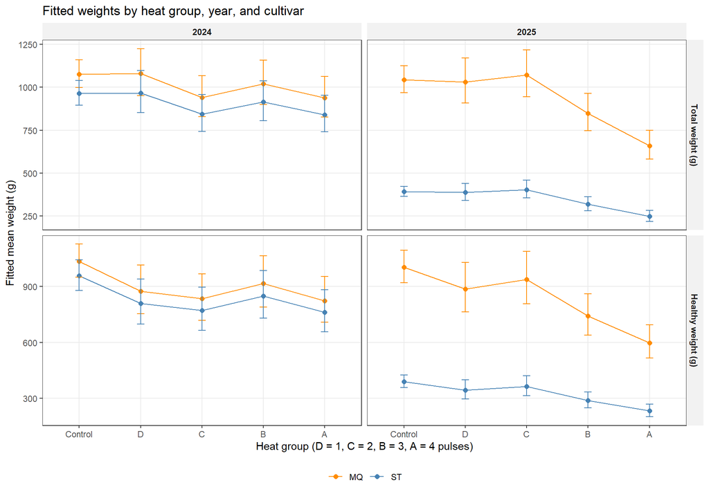

```r
emm_weight <- bind_rows(
  as.data.frame(summary(emmeans(f_total, ~ heat_group | year + cultivar, type = "response"))) %>%
    rename(emmean = response) %>%
    mutate(response = "Total weight (g)"),
  as.data.frame(summary(emmeans(f_healthy, ~ heat_group | year + cultivar, type = "response"))) %>%
    rename(emmean = response) %>%
    mutate(response = "Healthy weight (g)")
) %>%
  mutate(response = factor(response, levels = c("Total weight (g)", "Healthy weight (g)")))

ggplot(emm_weight, aes(x = heat_group, y = emmean, colour = cultivar, group = cultivar)) +
  geom_line() +
  geom_point(size = 2) +
  geom_errorbar(aes(ymin = lower.CL, ymax = upper.CL), width = 0.12) +
  facet_grid(response ~ year, scales = "free_y") +
  scale_colour_manual(values = c(MQ = "darkorange", ST = "steelblue")) +
  labs(x = "Heat group (D = 1, C = 2, B = 3, A = 4 pulses)",
       y = "Fitted mean weight (g)", colour = NULL,
       title = "Fitted weights by heat group, year, and cultivar") +
  theme_report()
```

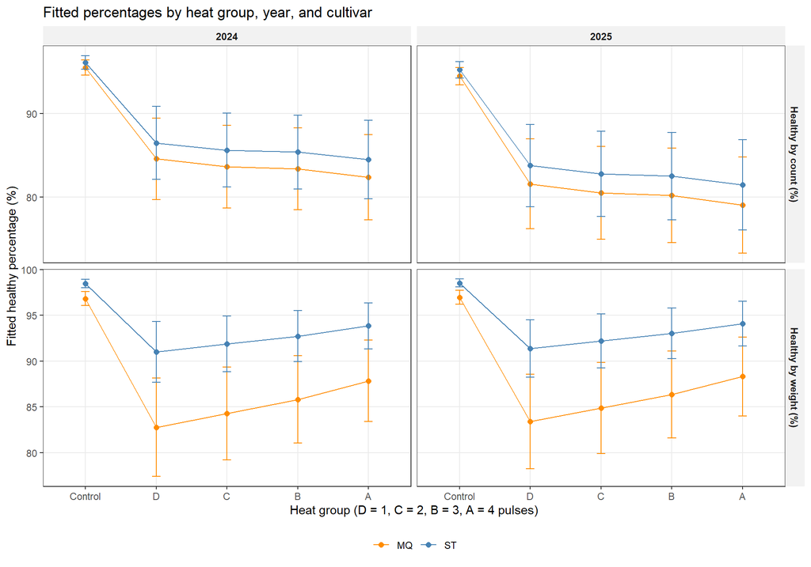

```r
prop_emm <- function(m, response) {
  s <- as.data.frame(summary(regrid(emmeans(m, ~ heat_group | year + cultivar), "response")))
  est_name <- setdiff(names(s), c("heat_group", "year", "cultivar", "SE", "df",
                                  "asymp.LCL", "asymp.UCL",
                                  "lower.CL", "upper.CL"))[1]
  data.frame(year = s$year, cultivar = s$cultivar, heat_group = s$heat_group,
             response = response, emmean = s[[est_name]],
             lower = s$asymp.LCL, upper = s$asymp.UCL,
             stringsAsFactors = FALSE)
}
emm_prop <- bind_rows(
  prop_emm(f_count, "Healthy by count (%)"),
  prop_emm(f_wpct,  "Healthy by weight (%)")
) %>%
  mutate(response = factor(response,
                           levels = c("Healthy by count (%)", "Healthy by weight (%)")))

ggplot(emm_prop, aes(x = heat_group, y = emmean, colour = cultivar, group = cultivar)) +
  geom_line() +
  geom_point(size = 2) +
  geom_errorbar(aes(ymin = lower, ymax = upper), width = 0.12) +
  facet_grid(response ~ year, scales = "free_y") +
  scale_colour_manual(values = c(MQ = "darkorange", ST = "steelblue")) +
  scale_y_continuous(labels = function(x) 100 * x) +
  labs(x = "Heat group (D = 1, C = 2, B = 3, A = 4 pulses)",
       y = "Fitted healthy percentage (%)", colour = NULL,
       title = "Fitted percentages by heat group, year, and cultivar") +
  theme_report()
```

```r
trend_rows <- function(fit, response) {
  ov <- as.data.frame(confint(linear_heat(fit)))
  ov_p <- as.data.frame(summary(linear_heat(fit)))$p.value
  yr <- as.data.frame(confint(linear_heat(fit, by = "year")))
  yr_p <- as.data.frame(summary(linear_heat(fit, by = "year")))$p.value
  data.frame(Response = response,
             Period = c("Overall", paste0(yr$year)),
             Ratio = c(ov$ratio, yr$ratio),
             Lower = c(ov$lower.CL, yr$lower.CL),
             Upper = c(ov$upper.CL, yr$upper.CL),
             p = c(ov_p, yr_p))
}
trend_tab <- bind_rows(
  trend_rows(f_total,   "Total weight"),
  trend_rows(f_healthy, "Healthy weight")
) %>%
  mutate(`Per-pulse ratio (95% CI)` = sprintf("%.3f (%.3f, %.3f)",
                                               Ratio, Lower, Upper),
         p = fmt_p(p)) %>%
  select(Response, Period, `Per-pulse ratio (95% CI)`, p)

kable(trend_tab,
      caption = "Per-pulse linear trend among A–D (Control excluded), overall and by year. The model has no heat × cultivar interaction, so the trend is common to MQ and ST.")
```

Per-pulse linear trend among A–D (Control excluded), overall and by year. The model has no heat × cultivar interaction, so the trend is common to MQ and ST.

| Response | Period | Per-pulse ratio (95% CI) | p |
| --- | --- | --- | --- |
| Total weight | Overall | 0.909 (0.875, 0.943) | <0.001 |
| Total weight | 2024 | 0.966 (0.916, 1.019) | 0.203 |
| Total weight | 2025 | 0.854 (0.810, 0.901) | <0.001 |
| Healthy weight | Overall | 0.927 (0.887, 0.970) | 0.001 |
| Healthy weight | 2024 | 0.991 (0.930, 1.055) | 0.773 |
| Healthy weight | 2025 | 0.868 (0.815, 0.924) | <0.001 |

The trend is computed only among A–D; Control is excluded. Because the selected weight model has no `heat_group × cultivar` interaction, the per-pulse trend is common to MQ and ST; only the year-specific trend differs.

# 6. Model checking

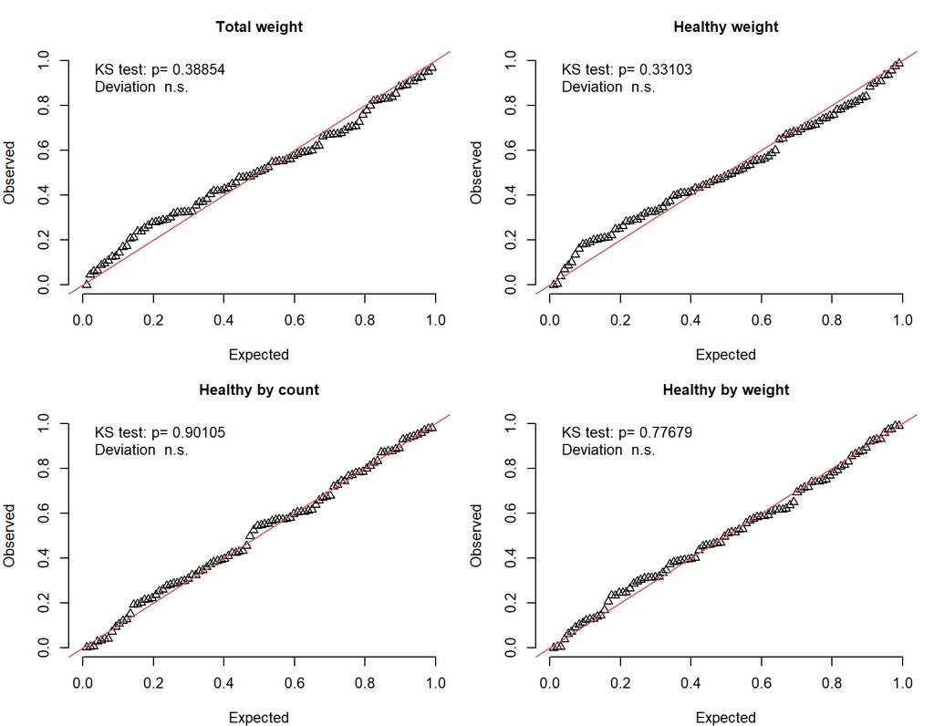

Figure 5. DHARMa QQ plots for the four final models.

```r
set.seed(628)
diag_list <- list(
  "Total weight" = f_total,
  "Healthy weight" = f_healthy,
  "Healthy by count" = f_count,
  "Healthy by weight" = f_wpct
)
diag_res <- lapply(diag_list, function(m) simulateResiduals(m, n = 500))

par(mfrow = c(2, 2), mar = c(4, 4, 3, 1))
for (nm in names(diag_res)) {
  plotQQunif(diag_res[[nm]], testDispersion = FALSE,
             testOutliers = FALSE, main = nm)
}
```

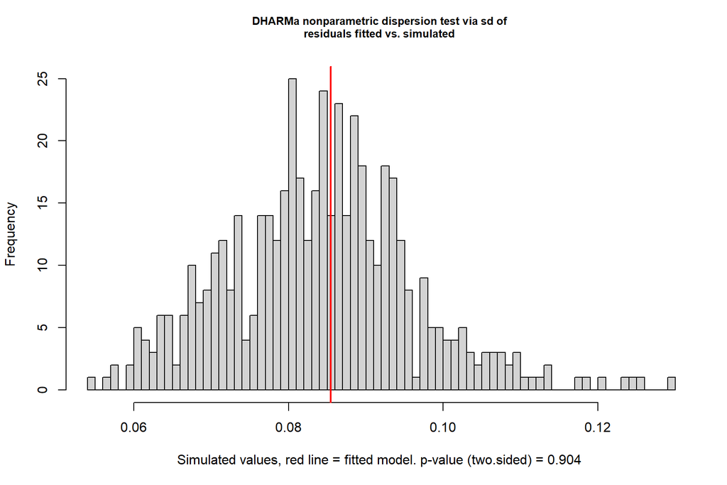

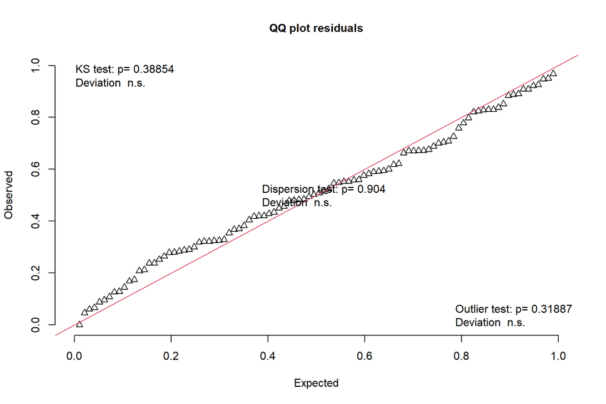

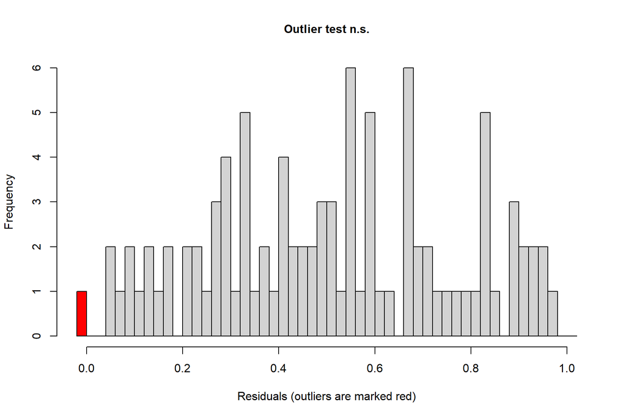

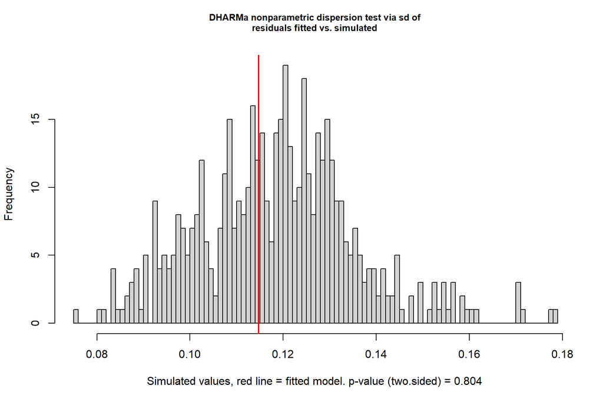

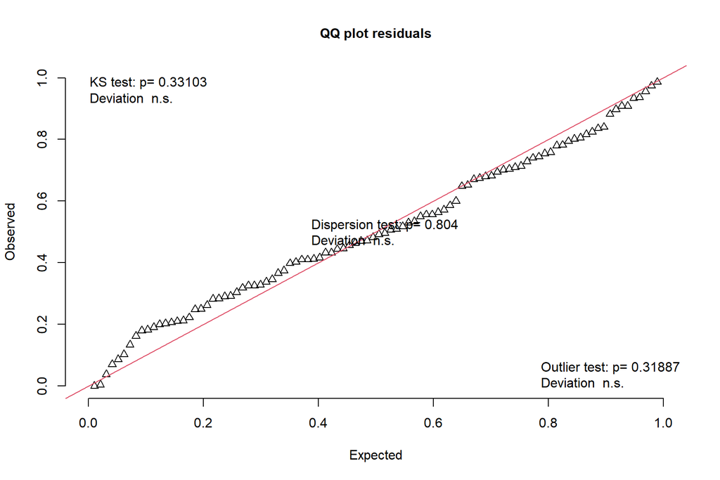

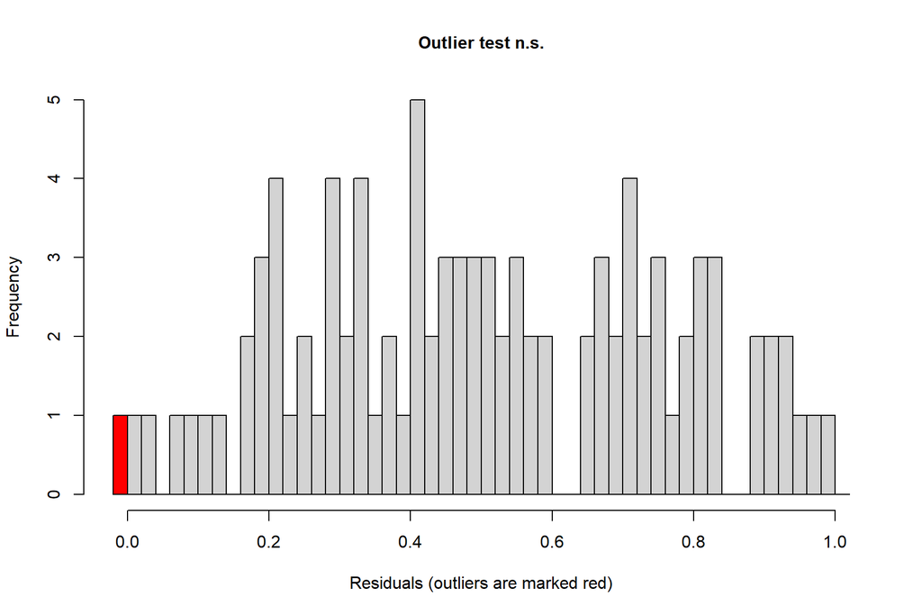

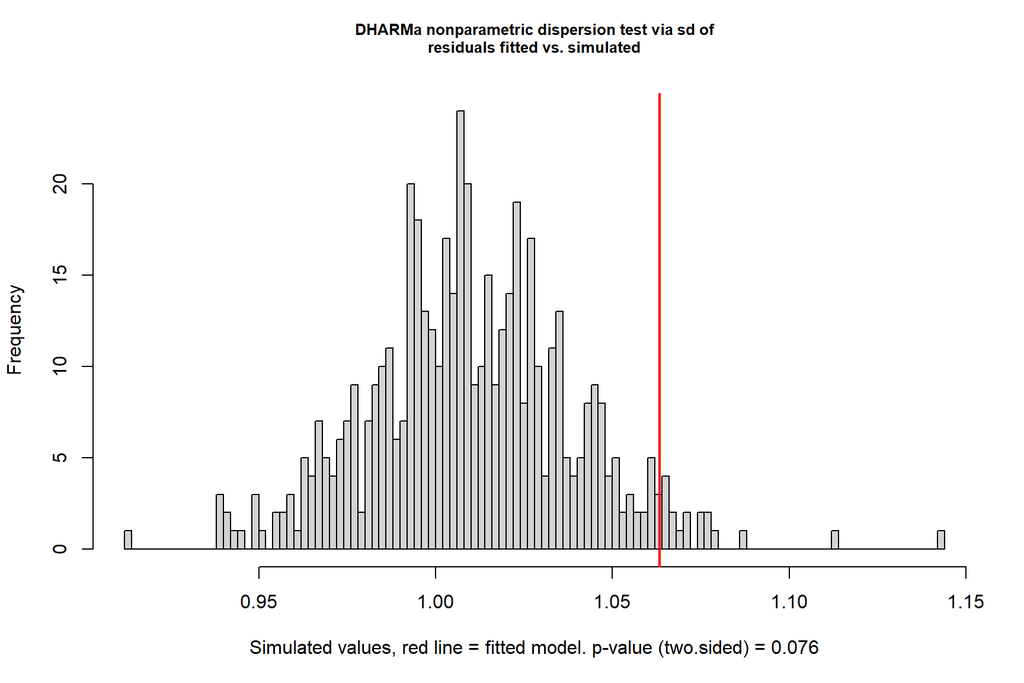

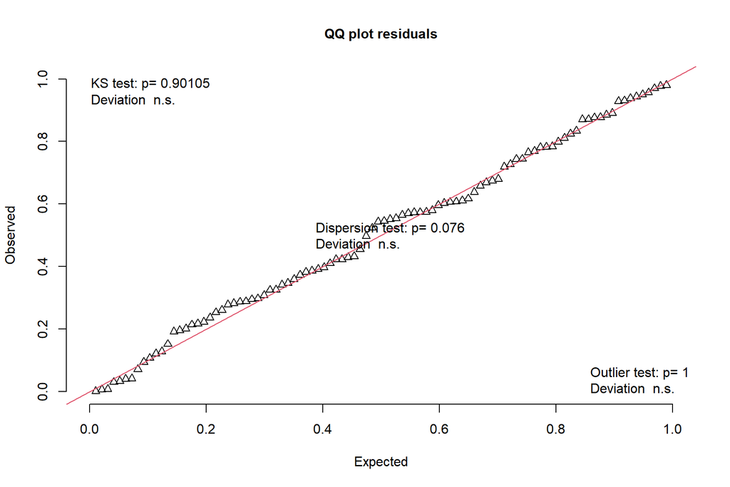

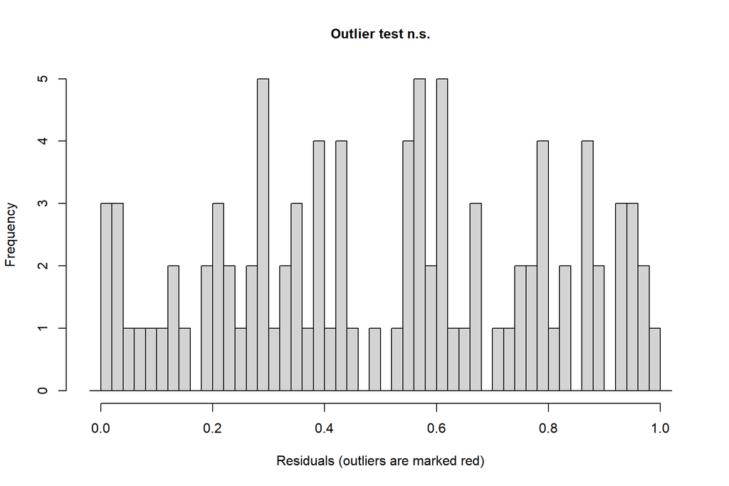

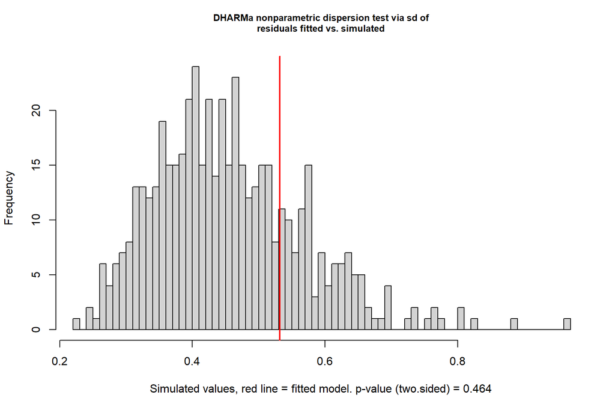

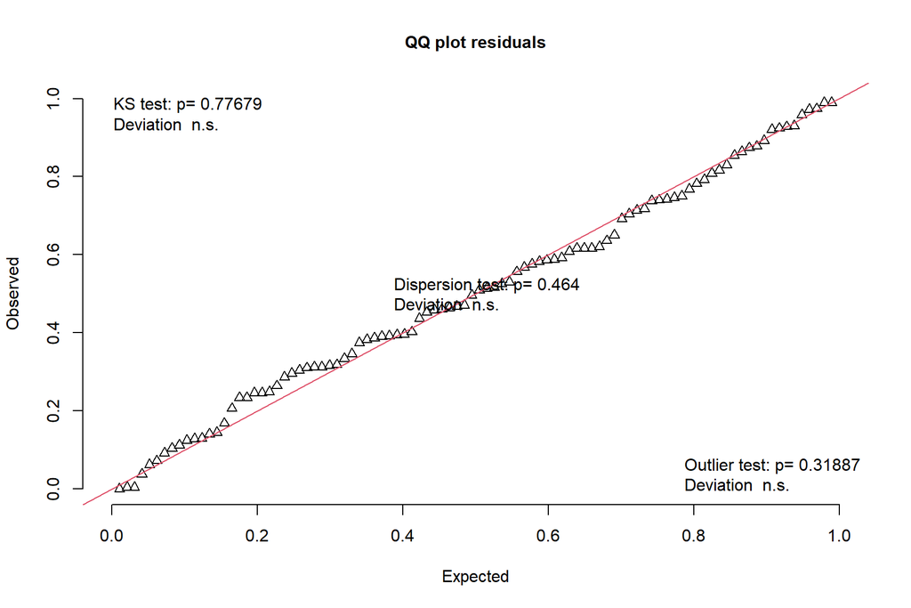

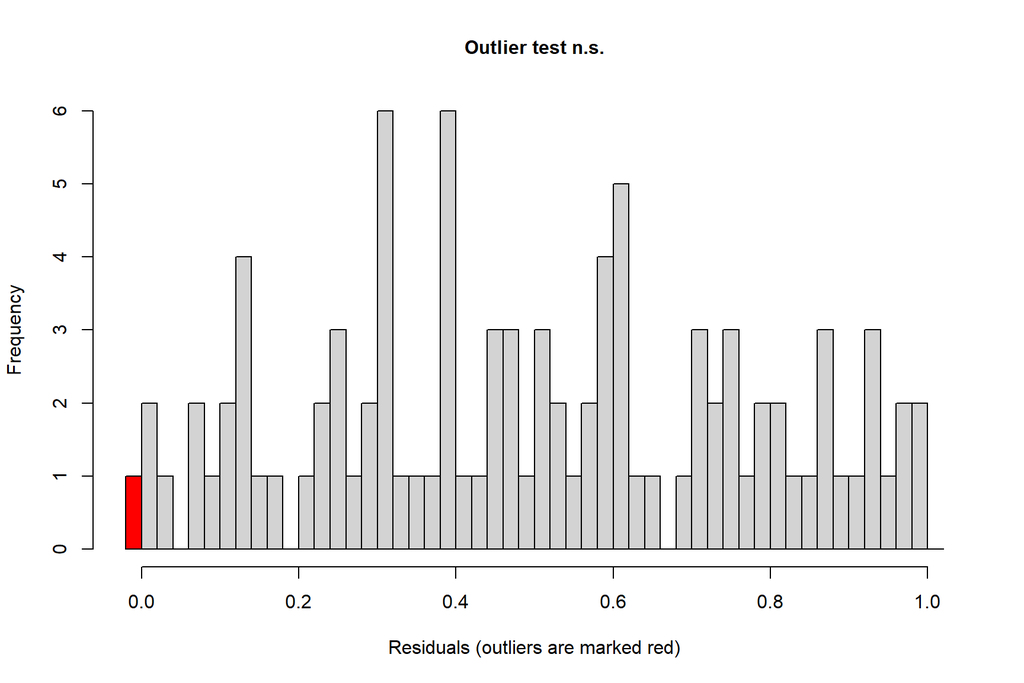

DHARMa residual diagnostics for the final models.

| Model | Dispersion | Uniformity | Outliers |
| --- | --- | --- | --- |
| Total weight | 0.904 | 0.389 | 0.319 |
| Healthy weight | 0.804 | 0.331 | 0.319 |
| Healthy by count | 0.076 | 0.901 | 1.000 |
| Healthy by weight | 0.464 | 0.777 | 0.319 |

```r
bind_rows(lapply(names(diag_res), function(nm) {
  r <- diag_res[[nm]]
  data.frame(Model = nm,
             Dispersion = fmt_p(testDispersion(r)$p.value),
             Uniformity = fmt_p(testUniformity(r)$p.value),
             Outliers = fmt_p(testOutliers(r)$p.value))
})) %>%
  kable(caption = "DHARMa residual diagnostics for the final models.")
```

```r
bind_rows(
  data.frame(Model = "Total weight",
             ICC = as.data.frame(VarCorr(f_total))$vcov[1] /
               sum(as.data.frame(VarCorr(f_total))$vcov)),
  data.frame(Model = "Healthy weight",
             ICC = as.data.frame(VarCorr(f_healthy))$vcov[1] /
               sum(as.data.frame(VarCorr(f_healthy))$vcov))
) %>%
  kable(digits = 3, caption = "Pair intraclass correlation for the weight models.")
```

Pair intraclass correlation for the weight models.

| Model | ICC |
| --- | --- |
| Total weight | 0.185 |
| Healthy weight | 0.107 |

Diagnostics are acceptable: dispersion, uniformity, and outlier tests are non-significant (the count model’s dispersion test is borderline, p ≈ 0.08). The pair random effect matters for the weights (ICC ≈ 0.19 total, 0.11 healthy); for the percentage models the pair variance is small and the treatment-specific dispersion captures most of the extra-binomial variation.

## 6.1 Sensitivity checks

```r
gamma_total <- glmmTMB(total_weight ~ heat_group * year + cultivar +
                         year:cultivar + (1 | pair),
                       data = d, family = Gamma(link = "log"))
gamma_healthy <- glmmTMB(healthy_weight ~ heat_group * year + cultivar +
                           year:cultivar + (1 | pair),
                         data = d, family = Gamma(link = "log"))

gamma_means <- function(m) {
  s <- as.data.frame(summary(emmeans(m, ~ heat_group, type = "response")))
  mean(s$response)  # average over the 5 heat groups
}
gamma_tab <- data.frame(
  Model = c("Total", "Healthy"),
  `Log-normal` = c(gamma_means(f_total), gamma_means(f_healthy)),
  Gamma = c(gamma_means(gamma_total), gamma_means(gamma_healthy))
)
kable(gamma_tab, col.names = c("Model", "Log-normal", "Gamma"),
      caption = "Sensitivity: average fitted weight (g) from the log-normal and Gamma models.")
```

Sensitivity: average fitted weight (g) from the log-normal and Gamma models.

| Model | Log-normal | Gamma |
| --- | --- | --- |
| Total | 736.8398 | 743.1597 |
| Healthy | 667.2672 | 676.6496 |

```r
d_drop <- d[!(d$year == "2025" & d$cultivar == "MQ" &
              d$intensity_group == "A" & d$treatment == "OTC" & d$plot == 2), ]
f_healthy_drop <- lmer(log(healthy_weight) ~ heat_group * year + cultivar +
                         year:cultivar + (1 | pair),
                       data = d_drop, REML = TRUE)
drop_avg <- as.data.frame(confint(contrast(
  emmeans(f_healthy_drop, ~ heat_group),
  list("Heat avg vs Control" = c(-1, .25, .25, .25, .25)),
  type = "response"
)))
cat(sprintf("Healthy-weight average heat/control ratio after dropping the most extreme plot: %.3f (%.3f, %.3f).\n",
            drop_avg$ratio, drop_avg$lower.CL, drop_avg$upper.CL))
```

```
Healthy-weight average heat/control ratio after dropping the most extreme plot: 0.816 (0.766, 0.868).
```

The Gamma model gives the same conclusions as the log-normal model, and dropping the most extreme healthy-weight plot changes the average heat/control ratio only slightly (0.804 → 0.816). The results are not driven by that one plot.

# 7. Summary for discussion

**Final models.**

| Response | Model | Selected because |
| --- | --- | --- |
| Total weight | `heat_group * year + cultivar + year:cultivar + (1\\|pair)` | heat profile differs by year; not by cultivar |
| Healthy weight | same | same |
| Healthy % by count | `heat_group + cultivar + year + (1\\|pair)`, beta-binomial | no heat interactions; additive |
| Healthy % by weight | same, beta | no heat interactions; additive |

**Key numbers.**

| Response | Control | Average of A–D | Effect |
| --- | --- | --- | --- |
| Total weight | 808 g | 715 g | −11.5% |
| Healthy weight | 789 g | 634 g | −19.6% |
| Healthy % by count | 95.4% | 83.1% | −12.3 pp (OR 0.24) |
| Healthy % by weight | 97.9% | 89.6% | −8.3 pp (OR 0.19) |

**What changes when Control and A–D are at the same level.**

- The **5-level factor** makes the heat profile explicit: each of A–D is compared with the same Control, and the model can test whether the *shape* of the profile differs by cultivar or year.
- The shape **does** differ by year for the weights (`heat_group × year` p = 0.0003 total, p = 0.006 healthy). In 2024 the per-pulse trend is weak (about −3%, p ≈ 0.20); in 2025 it is strong (about −15%, p < 0.0001). A binary `treatment × year` term would miss this, because it only allows the overall OTC-vs-Control shift to differ by year, not the A–D shape.
- The shape does **not** differ by cultivar for the weights (`heat_group × cultivar` p = 0.28/0.29), even though the binary treatment × cultivar test was borderline in the earlier parameterisation. The 4-df interaction has less power than the 1-df binary test, so the two parameterisations answer slightly different questions.
- For the percentage outcomes, the profile is **additive**: no heat × cultivar, no heat × year, and the four heat levels are similar. The heat effect is a step change, not a dose–response.
- **Pooling controls** is by design: all control plots are untreated. The separate-control check is not significant (H0 vs H4, 3 df: p = 0.79, 0.88, 0.12, 0.10), so the pooled-control model is used; the percentage checks are only moderately powered.

**Points to discuss tomorrow.**

1. **Heat × year for weights.** Is the stronger 2025 dose–response real, or is it driven by a few plots (e.g. the 2025 MQ A/B and ST A/B plots with high rot)? The sensitivity check drops the most extreme healthy-weight plot and the average effect is stable, but the year-specific A–D shape deserves a closer look.
2. **Heat × cultivar.** The 5-level test says no (p = 0.28/0.29); the binary treatment × cultivar test was borderline (p ≈ 0.05/0.046). Which parameterisation should we report? The 5-level model is the direct answer to “Control and A–D at the same level”; the binary model is more powerful for a single shift.
3. **Pooling controls.** The controls are untreated, so they are pooled by design. The separate-control check is not significant (p = 0.10–0.88), but the percentage checks are only moderately powered. Is the design-based pooling sufficient, or should we report the separate-control model as a sensitivity?
4. **Percentage model.** Additive 5-level model, no dose–response. Is the A–D difference (e.g. D worst for weight percentage, A worst for count) worth reporting, given that the per-pulse trend is not significant?
5. **Linear trend.** The per-pulse contrast is computed only among A–D; Control is excluded. Is the equal-spacing assumption (1, 2, 3, 4 pulses) defensible, given that pulse timing also differs?
6. **Sample size.** Three pairs per cell; the 4-df interactions are low-powered. Non-significant interactions should not be read as evidence of no effect.